# Session 4 exercise - Solutions

Last modified: 30 May 2019

# 1. Messy data - clean up using a work flow

Last week you cleaned up the `patient-data.txt` file using `mutate` and various `stringr` functions. This week we would like you to do the same again, but this time use the “pipe” (`%>%`) to do the clean up as a single workflow.

Assign the final cleaned data frame to a new object.

**There are various ways that this can be achieved the solution below is an example.**

```r
library(tidyverse)

cleaned_patients <- read.delim("data/patient-data.txt", stringsAsFactors = FALSE) %>%
  as_tibble() %>%
  mutate_all(str_trim) %>% # we can remove the leading/trailing spaces from all columns at once
  mutate(Sex = as.factor(Sex)) %>%
  mutate(Smokes = Smokes %in% c("TRUE", "Yes")) %>%
  mutate_at(vars(Height, Weight), str_remove, pattern = "kg|cm") %>% # the `|` in the pattern means OR
  mutate_at(vars(Height, Weight), as.numeric) %>%
  mutate(Birth = as.Date(Birth)) %>% # The `date` vector type works nicely now thanks to the package lubridate
  mutate(State = str_replace(State, "Californa", "California")) %>%
  mutate(State = str_to_title(State)) %>%  # fix "New york", "New jersey" and "indiana"
  mutate(State = as.factor(State)) %>%
  mutate(Grade_Level = na_if(Grade_Level, "99")) %>% # We'll assume the `99`s are supposed to be missing data
  mutate(Grade_Level = as.factor(Grade_Level)) %>% # although these are numbers, Grade is really a category
  mutate(Died = as.logical(Died)) %>%
  mutate(Date.Entered.Study = as.Date(Date.Entered.Study))

cleaned_patients
```

```
## # A tibble: 100 x 12
##    ID    Name  Sex   Smokes Height Weight Birth      State Grade_Level
##    <chr> <chr> <fct> <lgl>   <dbl>  <dbl> <date>     <fct> <fct>
##  1 AC/A… Mich… Male  FALSE    183.   76.6 1972-02-06 Geor… 2
##  2 AC/A… Derek Male  FALSE    179.   80.4 1972-06-15 Colo… 2
##  3 AC/A… Todd  Male  FALSE    169.   75.5 1972-07-09 New … 2
##  4 AC/A… Rona… Male  FALSE    176.   94.5 1972-08-17 Colo… 1
##  5 AC/A… Chri… Fema… FALSE    164.   71.8 1973-06-12 Geor… 2
##  6 AC/A… Dana  Fema… TRUE     158.   69.9 1973-07-01 Indi… 2
##  7 AC/A… Erin  Fema… FALSE    162.   68.8 1972-03-26 New … 1
##  8 AC/A… Rach… Fema… FALSE    166.   70.4 1973-05-11 Colo… 1
##  9 AC/A… Rona… Male  FALSE    181.   76.9 1971-12-31 Geor… 1
## 10 AC/A… Bryan Male  FALSE    167.   79.1 1973-07-19 New … 2
## # … with 90 more rows, and 3 more variables: Died <lgl>, Count <chr>,
## #   Date.Entered.Study <date>
```

# 2. Write a table to a file as part of a work flow

For this exercise use the clean data table `patient-data-cleaned.txt`.

We would like to output a subset of the data to a new file. To write to a file you will need to use a function we haven’t shown you, so you’ll have to check the `readr` package help pages to find the tidyverse write functions.

Use pipes to do this as a workflow.

The table should:

1. Have the columns the following columns **in this order**:  
   ID, Name, Sex, Smokes, BMI, Grade, Height, Weight  
   **The order of the columns in the resulting table is as specified in the `select` command**  
   **As we need the `State` column for step (d), it is best to leave the `select` until the end**
2. The Height column should be titled “Height (cm)”  
   **We could use `rename` but renaming can also be done during the `select` command**
3. The Weight should be in grams (it is currently in kg) and with an appropriate header
4. Only contain data for people from New York or New Jersey who are non-smokers
5. Be in tab separated value (tsv) format  
   **Because we are going to write this modified table to a file and then have no further use for it, there is no need to assign (`<-`) it to an object.**

```r
read_tsv("data/patient-data-cleaned.txt") %>%
    mutate(`Weight (g)` = Weight * 1000) %>%
    filter(str_detect(State, "New") & Smokes == "Non-Smoker") %>%
    select(ID, Name, Sex, Smokes, BMI, Grade, `Height (cm)` = Height, `Weight (g)`) %>%
    write_tsv("results/East_Coast_NonSmokers.txt")
```

# 3. Draw a plot as part of a work flow

For this exercise use the clean data table `patients-data-cleaned.txt`.

We would like you to modify the table and generate a scatter plot. Use pipes to do this as a workflow, including the ggplot as part of the workflow.

Create an xy scatter plot with Height on the x and Weight on the y where:

1. Height is in metres not centimetres
2. The plot only shows the data for people who are overweight and live in Colorado or Georgia  
   **`Overweight` is already a logical vector, so we can filter directly, there is no need to use `== TRUE`**
3. The x axis is labelled “Height (m)” - you can do this without using `labs` in the ggplot?
4. split the plot into two plots by state
5. colour the points by Sex

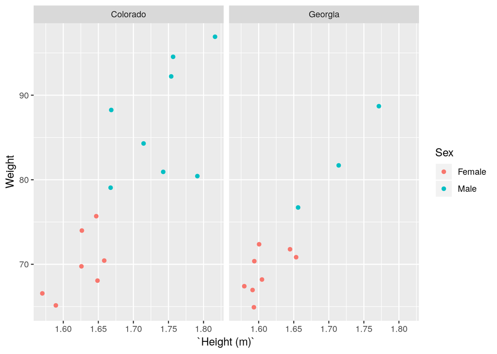

```r
read_tsv("data/patient-data-cleaned.txt") %>%
  mutate(`Height (m)` = Height * 0.01) %>%
  filter(State %in% c("Colorado", "Georgia")) %>%
  filter(Overweight) %>%
  mutate(Sex = as.factor(Sex)) %>%
  ggplot(aes(x = `Height (m)`, y = Weight)) +
      geom_point(aes(colour = Sex)) +
      facet_wrap(~ State)
```